# **How house attributes influence the sale price**

## Objectives

**Generate content to satisfy business requirement 1**:

- Determine how features are correlated to the target, and thus their significance in determining the sale price.

**Business requirement 2**:

- Determine which features are significant enough, with regard to predicting the sale price, to be studied in the exploratory data analysis notebook.
- house prices dataset: outputs/datasets/collection/house_prices.csv

## Outputs

**For use on the dashboard**:

- Code for calculating Spearman, phi_k correlation coefficients, significance values and PPS's.
- Code to produce heatmaps for the coefficients and PPS's.
- Code to produce scatter plots for feature-target pairs.
- Cleaned dataset for correlation tests: outputs/datasets/sale_price_study/cleaned/house_prices.csv
- categorical feature encoded dataset: outputs/datasets/sale_price_study/cleaned/encoded_house_prices.csv
- pickled selected significant features list: outputs/selected_significant_features.pkl

## Change working directory

Working directory changed to its parent folder.

```python
import os
current_dir = os.getcwd()
current_dir
```

```
'/workspace/heritage_housing_issues/jupyter_notebooks'
```

```python
os.chdir(os.path.dirname(current_dir))
os.getcwd()
```

```
'/workspace/heritage_housing_issues'
```

## Load house prices dataset

```python
import pandas as pd

house_prices_df = pd.read_csv(filepath_or_buffer='outputs/datasets/collection/house_prices.csv')
house_prices_df.dtypes
```

```
1stFlrSF             int64
2ndFlrSF           float64
BedroomAbvGr       float64
BsmtExposure        object
BsmtFinSF1           int64
BsmtFinType1        object
BsmtUnfSF            int64
EnclosedPorchSF    float64
GarageArea           int64
GarageFinish        object
GarageYrBlt        float64
GrLivArea            int64
KitchenQual         object
LotArea              int64
LotFrontage        float64
MasVnrArea         float64
OpenPorchSF          int64
OverallCond          int64
OverallQual          int64
TotalBsmtSF          int64
WoodDeckSF         float64
YearBuilt            int64
YearRemodAdd         int64
SalePrice            int64
dtype: object
```

## Dealing with missing data

Discover columns with missing data

```python
missing_data_df = house_prices_df.loc[:, house_prices_df.isna().any()]
print(missing_data_df.info())
house_prices_numeric_df = house_prices_df.select_dtypes(exclude=['object']).drop(['SalePrice'], axis=1)
print(house_prices_numeric_df.columns)
house_prices_non_numeric_df = house_prices_df.select_dtypes(include='object')
house_prices_non_numeric_df.columns
```

```
<class 'pandas.core.frame.DataFrame'>
RangeIndex: 1460 entries, 0 to 1459
Data columns (total 9 columns):
 #   Column           Non-Null Count  Dtype
---  ------           --------------  -----
 0   2ndFlrSF         1374 non-null   float64
 1   BedroomAbvGr     1361 non-null   float64
 2   BsmtFinType1     1346 non-null   object
 3   EnclosedPorchSF  136 non-null    float64
 4   GarageFinish     1298 non-null   object
 5   GarageYrBlt      1379 non-null   float64
 6   LotFrontage      1201 non-null   float64
 7   MasVnrArea       1452 non-null   float64
 8   WoodDeckSF       155 non-null    float64
dtypes: float64(7), object(2)
memory usage: 102.8+ KB
None
Index(['1stFlrSF', '2ndFlrSF', 'BedroomAbvGr', 'BsmtFinSF1', 'BsmtUnfSF',
       'EnclosedPorchSF', 'GarageArea', 'GarageYrBlt', 'GrLivArea', 'LotArea',
       'LotFrontage', 'MasVnrArea', 'OpenPorchSF', 'OverallCond',
       'OverallQual', 'TotalBsmtSF', 'WoodDeckSF', 'YearBuilt',
       'YearRemodAdd'],
      dtype='object')
```

```
Index(['BsmtExposure', 'BsmtFinType1', 'GarageFinish', 'KitchenQual'], dtype='object')
```

**Impute missing values in numeric columns**.  
Want to choose an impute method that does not distort the distribution significantly, whilst preserving any existing correlations. With this in mind the KNNImputer is employed with 5 nearest neighbours used.

```
1stFlrSF           0
2ndFlrSF           0
BedroomAbvGr       0
BsmtFinSF1         0
BsmtUnfSF          0
EnclosedPorchSF    0
GarageArea         0
GarageYrBlt        0
GrLivArea          0
LotArea            0
LotFrontage        0
MasVnrArea         0
OpenPorchSF        0
OverallCond        0
OverallQual        0
TotalBsmtSF        0
WoodDeckSF         0
YearBuilt          0
YearRemodAdd       0
dtype: int64
```

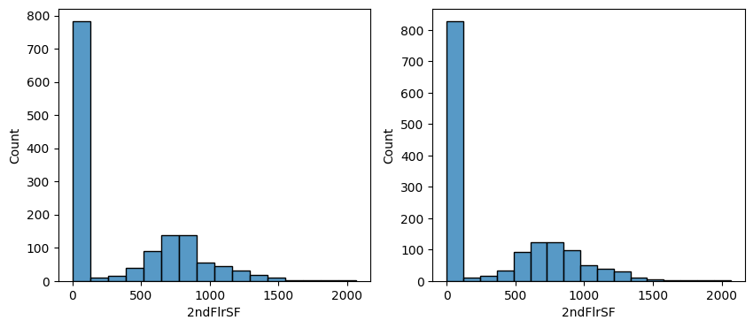

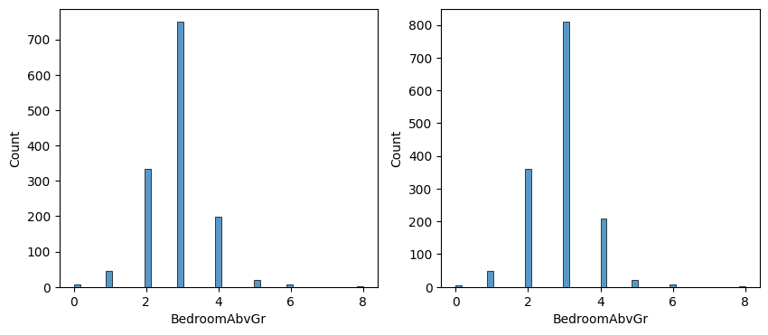

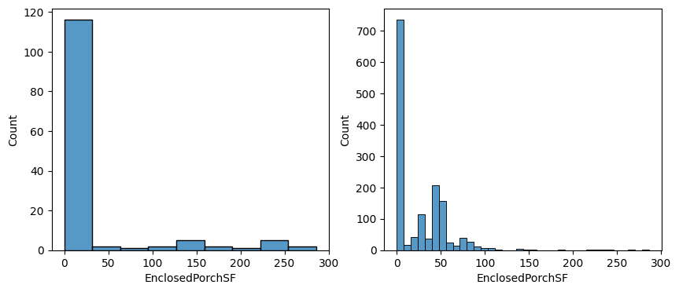

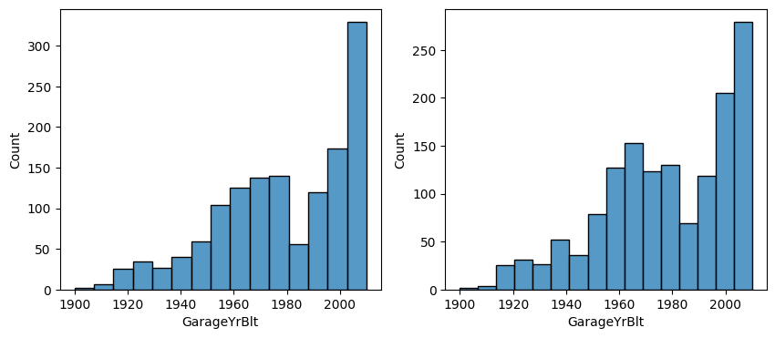

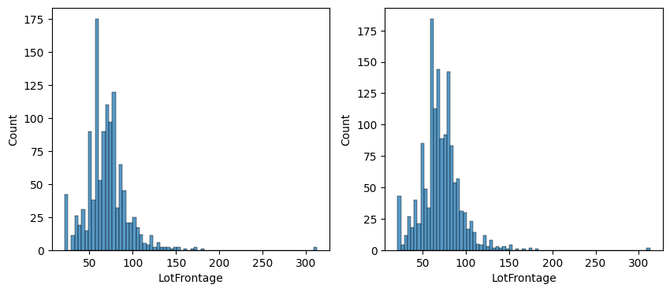

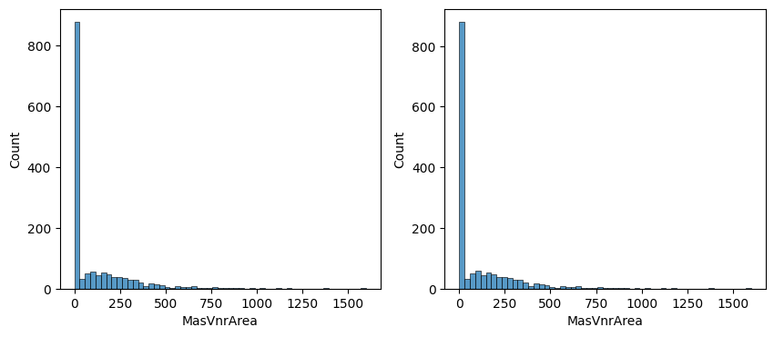

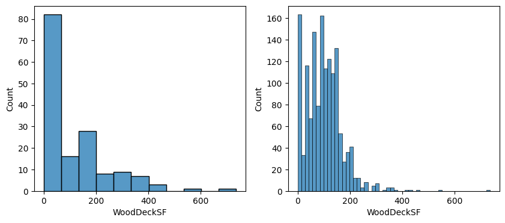

```python
from sklearn.impute import KNNImputer
import seaborn as sns
import matplotlib.pyplot as plt

# plotting distributions for numeric variables with missing data
counter = 0
imputed_columns = []
while counter < len(house_prices_numeric_df.columns):
    if house_prices_numeric_df.iloc[:, counter].name in missing_data_df.columns:
        fig, ax = plt.subplots(ncols=2, nrows=1, figsize=(10,4))
        sns.histplot(x=house_prices_numeric_df.iloc[:, counter], ax=ax[0])
        imputed_columns.append(house_prices_numeric_df.iloc[:, counter].name)
    counter += 1

# Imputing the missing values for required columns
imputer = KNNImputer()
imputer.set_output(transform='pandas')
house_prices_numeric_df = imputer.fit_transform(house_prices_numeric_df)
print(house_prices_numeric_df.isna().sum())
house_prices_df[house_prices_numeric_df.columns.values] = house_prices_numeric_df

for col in ['BedroomAbvGr','GarageYrBlt','OverallCond','OverallQual','YearBuilt', 'YearRemodAdd']:
    house_prices_numeric_df[col] = house_prices_numeric_df[col].round()

# plotting distributions after imputation on same figures, for visual comparison
for fig in plt.get_fignums():
    sns.histplot(x=house_prices_numeric_df[imputed_columns[fig - 1]], ax=plt.figure(fig).get_axes()[1])
```

Inspection of the above figures showing the variable distributions before and after imputation, shows that apart from the 'EnclosedPorchSF' and 'WoodDeckSF' variables, there is no noticeable change to the distribution shapes. In the case of the EnclosedPorchSF variable, a large quantity of data was missing, so the somewhat noticeable change is inevitable; the same is true for the WoodDeckSF variable.

**Impute missing values in non-numeric columns**.  
In the absence of a viable distance metric, and considering the fact that only a small amount of data is missing, the KNNImputer was not used. Instead the more simple method for filling the values by cycling through the possible values was used.

```
Index(['BsmtFinType1', 'GarageFinish'], dtype='object')
```

```
1stFlrSF           0
2ndFlrSF           0
BedroomAbvGr       0
BsmtExposure       0
BsmtFinSF1         0
BsmtFinType1       0
BsmtUnfSF          0
EnclosedPorchSF    0
GarageArea         0
GarageFinish       0
GarageYrBlt        0
GrLivArea          0
KitchenQual        0
LotArea            0
LotFrontage        0
MasVnrArea         0
OpenPorchSF        0
OverallCond        0
OverallQual        0
TotalBsmtSF        0
WoodDeckSF         0
YearBuilt          0
YearRemodAdd       0
SalePrice          0
dtype: int64
```

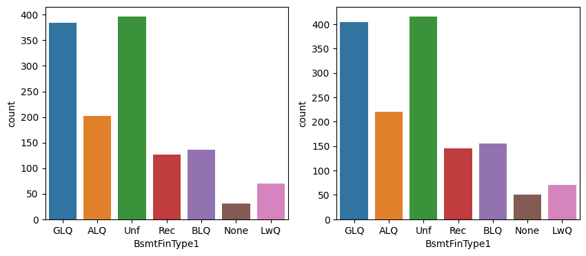

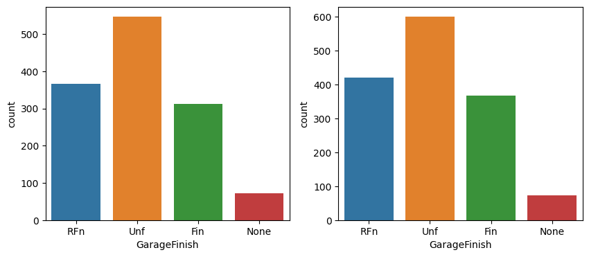

```python
missing_data_non_numeric_df = missing_data_df.select_dtypes(include='object')
print(missing_data_non_numeric_df.columns)

# plotting the variable distributions before imputation
counter = 0
imputed_columns = []
while counter < len(missing_data_non_numeric_df.columns):
    fig, ax = plt.subplots(ncols=2, nrows=1, figsize=(10,4))
    sns.countplot(x=missing_data_non_numeric_df.iloc[:, counter], ax=ax[0])
    imputed_columns.append(missing_data_non_numeric_df.iloc[:, counter].name)
    counter += 1

# imputing the missing values
for col in imputed_columns:
    number_of_nans = house_prices_df[col].loc[(house_prices_df[col].isna() == True)].size
    unique_values = house_prices_df[col].unique()
    index_no = 0
    while number_of_nans > 0:
        if index_no + 1 >= unique_values.size:
            index_no = 0
        house_prices_df[col].fillna(value=unique_values[index_no], limit=1, inplace=True)
        index_no += 1
        number_of_nans = house_prices_df[col].loc[(house_prices_df[col].isna() == True)].size

# plotting the distributions on the same figures after imputation for comparison
for fig in plt.get_fignums():
    sns.countplot(x=house_prices_df[imputed_columns[fig - 1]], ax=plt.figure(fig).get_axes()[1])

house_prices_df.isna().sum()
```

Can see from the above figures that there are no significant changes in the distribution shapes.

### Save cleaned dataset

Needed for the dashboard, for the sale price correlation study page code.

```python
try:
    path = os.path.join(os.getcwd(), 'outputs/datasets/sale_price_study/cleaned')
    os.makedirs(path)
except Exception as e:
  print(e)
```

```
[Errno 17] File exists: '/workspace/heritage_housing_issues/outputs/datasets/sale_price_study/cleaned'
```

```python
try:
    house_prices_df.to_csv(os.path.join(path, 'house_prices.csv'), index=False)
except Exception as e:
    print(e)
```

## Correlation matrices for features and target: sale price

### Normality test for sale price

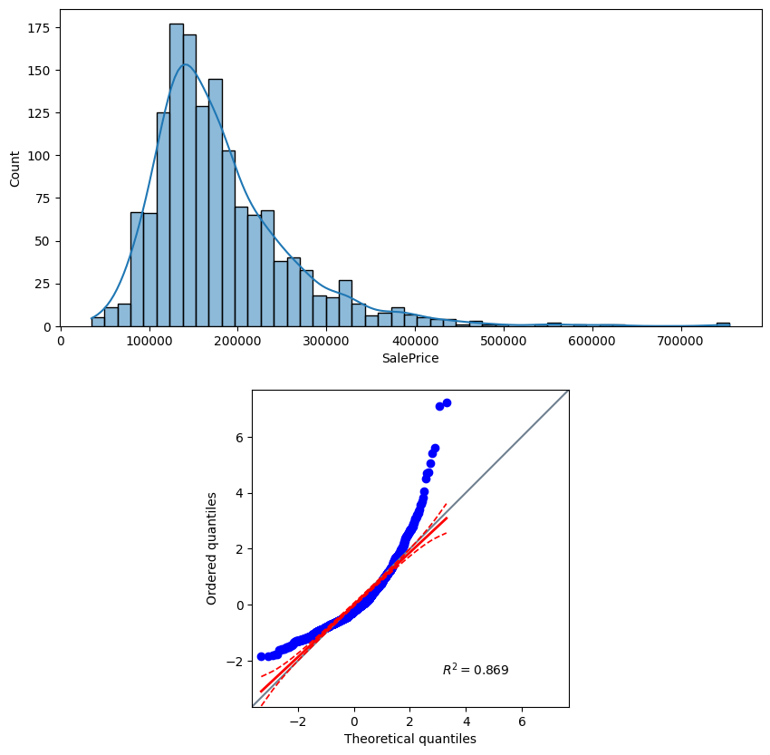

```python
import pingouin as pg

fig, axes = plt.subplots(nrows=2, figsize=(10,10))
sns.histplot(x=house_prices_df['SalePrice'], kde=True, ax=axes[0])
pg.qqplot(x=house_prices_df['SalePrice'], ax=axes[1])
```

```python
print('skew:', house_prices_df['SalePrice'].skew())
print('kurtosis:', house_prices_df['SalePrice'].kurtosis())
pg.normality(house_prices_df['SalePrice'])
```

```
skew: 1.8828757597682129
kurtosis: 6.536281860064529
```

|  | W | pval | normal |
| --- | --- | --- | --- |
| SalePrice | 0.869673 | 3.207204e-33 | False |

Examining the sale price histogram, QQ-plot, values of the skew and kutosis, as well as the Shapiro-Wilk normality test, shows that the sale price is not normally distributed. It is also known that many of the features are not normally distributed and may have possible outliers; as such considering the value-time tradeoff, the pearson correlation test will not be used. To use it would require an attempt to transform the distributions in order to normalise them (if possible), as well as remove any outliers.

**Instead the Spearman and phi_k correlation coefficients will be calculated**.

### Spearman

**Categorical variable encoding**:

```python
house_prices_categorical_df = house_prices_df.select_dtypes(include='object')
house_prices_categorical_df.columns
```

```
Index(['BsmtExposure', 'BsmtFinType1', 'GarageFinish', 'KitchenQual'], dtype='object')
```

All categorical variables are ordinal, therefore use ordinal encoding.

```python
from sklearn.preprocessing import OrdinalEncoder
import numpy as np

bsmt_fin_type1_cat = np.array(list(reversed(['GLQ', 'ALQ', 'BLQ', 'Rec', 'LwQ', 'Unf', 'None'])))
bsmt_exposure_cat = np.array(['None', 'No', 'Mn', 'Av', 'Gd'])
garage_finish_cat = np.array(['None', 'Unf', 'RFn', 'Fin'])
kitchen_quality_cat = np.array(['Po', 'Fa', 'TA', 'Gd', 'Ex'])

categories = [bsmt_exposure_cat, bsmt_fin_type1_cat, garage_finish_cat, kitchen_quality_cat]
encoder = OrdinalEncoder(categories=categories, dtype='int64')
encoder.set_output(transform='pandas')


house_prices_df[house_prices_categorical_df.columns] = encoder.fit_transform(X=house_prices_categorical_df)
house_prices_df[house_prices_categorical_df.columns].head()
```

|  | BsmtExposure | BsmtFinType1 | GarageFinish | KitchenQual |
| --- | --- | --- | --- | --- |
| 0 | 1 | 6 | 2 | 3 |
| 1 | 4 | 5 | 2 | 2 |
| 2 | 2 | 6 | 2 | 3 |
| 3 | 1 | 5 | 1 | 3 |
| 4 | 3 | 6 | 2 | 3 |

```python
try:
    path = os.path.join(os.getcwd(), 'outputs/datasets/sale_price_study/cleaned')
    os.makedirs(path)
except Exception as e:
  print(e)
```

```
[Errno 17] File exists: '/workspace/heritage_housing_issues/outputs/datasets/sale_price_study/cleaned'
```

```python
try:
    house_prices_df.to_csv(os.path.join(path, 'encoded_house_prices.csv'), index=False)
except Exception as e:
    print(e)
```

Chosen significance level value: 0.05

```python
spearman_df = house_prices_df.pairwise_corr(columns=['SalePrice'], alternative='greater', method='spearman')
spearman_df
```

|  | X | Y | method | alternative | n | r | CI95% | p-unc | power |
| --- | --- | --- | --- | --- | --- | --- | --- | --- | --- |
| 0 | SalePrice | 1stFlrSF | spearman | greater | 1460 | 0.575408 | [0.55, 1.0] | 8.901231e-130 | 1.000000e+00 |
| 1 | SalePrice | 2ndFlrSF | spearman | greater | 1460 | 0.289224 | [0.25, 1.0] | 7.889663e-30 | 1.000000e+00 |
| 2 | SalePrice | BedroomAbvGr | spearman | greater | 1460 | 0.240768 | [0.2, 1.0] | 5.322561e-21 | 1.000000e+00 |
| 3 | SalePrice | BsmtExposure | spearman | greater | 1460 | 0.344207 | [0.31, 1.0] | 3.587931e-42 | 1.000000e+00 |
| 4 | SalePrice | BsmtFinSF1 | spearman | greater | 1460 | 0.301871 | [0.26, 1.0] | 1.928955e-32 | 1.000000e+00 |
| 5 | SalePrice | BsmtFinType1 | spearman | greater | 1460 | 0.338775 | [0.3, 1.0] | 7.783382e-41 | 1.000000e+00 |
| 6 | SalePrice | BsmtUnfSF | spearman | greater | 1460 | 0.185197 | [0.14, 1.0] | 4.943430e-13 | 1.000000e+00 |
| 7 | SalePrice | EnclosedPorchSF | spearman | greater | 1460 | -0.217160 | [-0.26, 1.0] | 1.000000e+00 | 3.713436e-24 |
| 8 | SalePrice | GarageArea | spearman | greater | 1460 | 0.649379 | [0.62, 1.0] | 6.604590e-176 | 1.000000e+00 |
| 9 | SalePrice | GarageFinish | spearman | greater | 1460 | 0.562122 | [0.53, 1.0] | 1.078651e-122 | 1.000000e+00 |
| 10 | SalePrice | GarageYrBlt | spearman | greater | 1460 | 0.600378 | [0.57, 1.0] | 5.256448e-144 | 1.000000e+00 |
| 11 | SalePrice | GrLivArea | spearman | greater | 1460 | 0.731310 | [0.71, 1.0] | 7.155077e-245 | 1.000000e+00 |
| 12 | SalePrice | KitchenQual | spearman | greater | 1460 | 0.672849 | [0.65, 1.0] | 2.200255e-193 | 1.000000e+00 |
| 13 | SalePrice | LotArea | spearman | greater | 1460 | 0.456461 | [0.42, 1.0] | 2.435790e-76 | 1.000000e+00 |
| 14 | SalePrice | LotFrontage | spearman | greater | 1460 | 0.405587 | [0.37, 1.0] | 3.220681e-59 | 1.000000e+00 |
| 15 | SalePrice | MasVnrArea | spearman | greater | 1460 | 0.423659 | [0.39, 1.0] | 5.741192e-65 | 1.000000e+00 |
| 16 | SalePrice | OpenPorchSF | spearman | greater | 1460 | 0.477561 | [0.44, 1.0] | 2.430049e-84 | 1.000000e+00 |
| 17 | SalePrice | OverallCond | spearman | greater | 1460 | -0.129325 | [-0.17, 1.0] | 9.999996e-01 | 1.912054e-11 |
| 18 | SalePrice | OverallQual | spearman | greater | 1460 | 0.809829 | [0.79, 1.0] | 0.000000e+00 | 1.000000e+00 |
| 19 | SalePrice | TotalBsmtSF | spearman | greater | 1460 | 0.602725 | [0.57, 1.0] | 2.078650e-145 | 1.000000e+00 |
| 20 | SalePrice | WoodDeckSF | spearman | greater | 1460 | 0.135635 | [0.09, 1.0] | 9.844871e-08 | 9.998190e-01 |
| 21 | SalePrice | YearBuilt | spearman | greater | 1460 | 0.652682 | [0.63, 1.0] | 2.846920e-178 | 1.000000e+00 |
| 22 | SalePrice | YearRemodAdd | spearman | greater | 1460 | 0.571159 | [0.54, 1.0] | 1.778617e-127 | 1.000000e+00 |

Saving the spearman_df dataframe

```python
try:
    path = os.path.join(os.getcwd(), 'src/sale_price_study/')
    os.makedirs(path)
except Exception as e:
  print(e)
```

```
[Errno 17] File exists: '/workspace/heritage_housing_issues/src/sale_price_study/'
```

```python
try:
    spearman_df.to_csv(os.path.join(path, 'spearman_df.csv'), index=False)
except Exception as e:
    print(e)
```

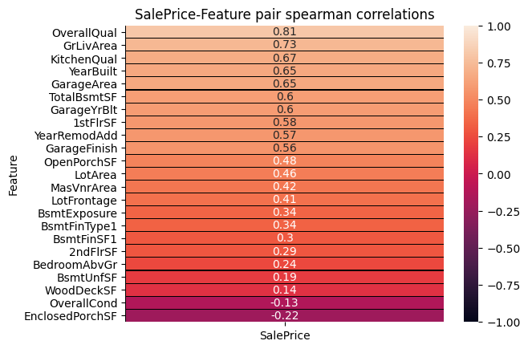

```python
spearman_heatmap = sns.heatmap(spearman_df.pivot(index='Y', columns=['X'], values=['r']).sort_values(by=('r', 'SalePrice'), ascending=False), annot=True,
                                              vmax=1, vmin=-1, xticklabels=['SalePrice'], linecolor='black', linewidth=0.05)
spearman_heatmap.set(xlabel='', ylabel='Feature', title='SalePrice-Feature pair spearman correlations')
spearman_heatmap
```

Evaluation of the coefficients and their associated p values implies the following outcomes with regard to accepting the common alternative hypotheses that the correlation coefficients are greater than zero or equivalently the correlations are positive monotonic:

```python
print(f'|Feature|Null hypothesis (r≤0) outcome|')
for feature_name in house_prices_df.columns:
    if feature_name not in ['OverallCond', 'EnclosedPorchSF', 'SalePrice']:
        print(f'{feature_name}:', 'reject' )
    elif feature_name in ['OverallCond', 'EnclosedPorchSF']:
        print(f'{feature_name}:', 'accept' )
```

```
|Feature|Null hypothesis (r≤0) outcome|
1stFlrSF: reject
2ndFlrSF: reject
BedroomAbvGr: reject
BsmtExposure: reject
BsmtFinSF1: reject
BsmtFinType1: reject
BsmtUnfSF: reject
EnclosedPorchSF: accept
GarageArea: reject
GarageFinish: reject
GarageYrBlt: reject
GrLivArea: reject
KitchenQual: reject
LotArea: reject
LotFrontage: reject
MasVnrArea: reject
OpenPorchSF: reject
OverallCond: accept
OverallQual: reject
TotalBsmtSF: reject
WoodDeckSF: reject
YearBuilt: reject
YearRemodAdd: reject
```

Therefore the Size group and Quality group (alternative) hypotheses, can be accepted: namely there exists statistically significant positive monotonic correlations between those features and the sale price. The same is true for the Age/Condition group and feature group 4, except for the features 'OverallCond' and 'EnclosedPorch', where the correlation has a negative value, and could well be zero as indicated by the 95% confidence intervals.

```python
print(f'|Feature|Strength|')
strong_features = []
moderate_features = []
weak_features = []
for feature_name, r_value in spearman_df[['Y', 'r']].set_index('Y').iterrows():
    strength = ''
    if abs(r_value.values[0]) > 0.65:
        strength = 'strong'
        strong_features.append((feature_name, r_value))
    elif abs(r_value.values[0]) > 0.35:
        strength = 'moderate'
        moderate_features.append((feature_name, r_value))
    elif abs(r_value.values[0]) > 0:
        strength = 'weak'
        weak_features.append((feature_name, r_value))

for feature_tuple in strong_features:
    print(f'{feature_tuple[0]}:', 'strong')
for feature_tuple in moderate_features:
    print(f'{feature_tuple[0]}:', 'moderate')
for feature_tuple in weak_features:
    print(f'{feature_tuple[0]}:', 'weak')
```

```
|Feature|Strength|
GrLivArea: strong
KitchenQual: strong
OverallQual: strong
YearBuilt: strong
1stFlrSF: moderate
GarageArea: moderate
GarageFinish: moderate
GarageYrBlt: moderate
LotArea: moderate
LotFrontage: moderate
MasVnrArea: moderate
OpenPorchSF: moderate
TotalBsmtSF: moderate
YearRemodAdd: moderate
2ndFlrSF: weak
BedroomAbvGr: weak
BsmtExposure: weak
BsmtFinSF1: weak
BsmtFinType1: weak
BsmtUnfSF: weak
EnclosedPorchSF: weak
OverallCond: weak
WoodDeckSF: weak
```

- Only 'GrLivArea' of the size group is as predicted; all the basement related features (except for 'TotalBsmtSF) expressed weak correlations with the sale price; the lot based features have moderate correlations. More surprisingly the '2ndFlrSF' and 'BedroomAbvGrade' features are only weakly correlated to the sale price; in the case of '2ndFlrSf', this may be because of the large number of instances with the value 0 impacting the r coefficient value.
- For the quality group both 'KitchenQual' and 'OverallQual' are strongly correlated as predicted.
- For the Age/Condition group, only 'YearRemodAdd' is as expected, with 'YearBuilt' being strongly correlated, and 'OverallCond being weakly correlated with sale price.
- For feature group 4, somewhat surprisingly the garage related features are all moderately correlated to sale price; also unexpected is the moderate correlation with sale price for the 'MasVnrArea' and 'OpenPorchSF' features. The remaining feature correlation strengths are as predicted.

### Phi_k correlation test

```
interval columns not set, guessing: ['1stFlrSF', '2ndFlrSF', 'BedroomAbvGr', 'BsmtExposure', 'BsmtFinSF1', 'BsmtFinType1', 'BsmtUnfSF', 'EnclosedPorchSF', 'GarageArea', 'GarageFinish', 'GarageYrBlt', 'GrLivArea', 'KitchenQual', 'LotArea', 'LotFrontage', 'MasVnrArea', 'OpenPorchSF', 'OverallCond', 'O…
```

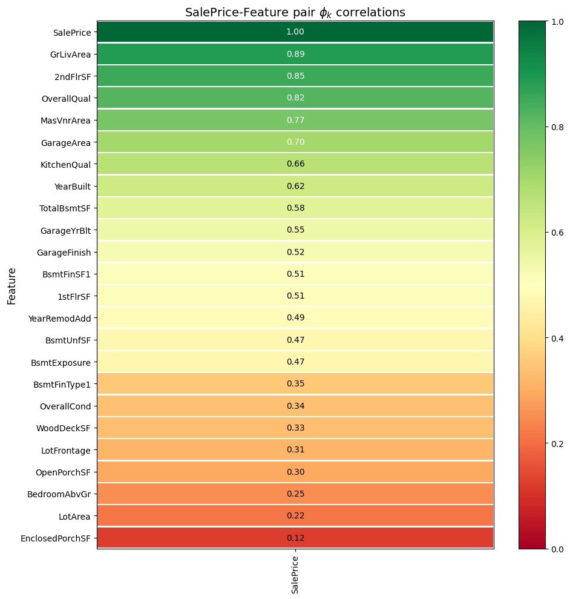

```python
import phik
from phik.phik import phik_matrix
from phik.report import plot_correlation_matrix

phik_matrix_df = pd.DataFrame(phik.phik_matrix(house_prices_df)['SalePrice'].sort_values())
matrix_plot = plot_correlation_matrix(phik_matrix_df.values, x_labels=phik_matrix_df.columns, y_labels=phik_matrix_df.index, figsize=(10,10), vmin=0, vmax=1,
                                      y_label='Feature', title='SalePrice-Feature pair $\phi_k$ correlations ')
matrix_plot
```

Saving the phi_k matrix

```python
try:
    phik_matrix_df.to_csv(os.path.join(path, 'phik_matrix_df.csv'), index=True)
except Exception as e:
    print(e)
```

**Significance**:

```python
from phik.significance import significance_matrix
significance_matrix_df = significance_matrix(house_prices_df)
```

```
interval columns not set, guessing: ['1stFlrSF', '2ndFlrSF', 'BedroomAbvGr', 'BsmtExposure', 'BsmtFinSF1', 'BsmtFinType1', 'BsmtUnfSF', 'EnclosedPorchSF', 'GarageArea', 'GarageFinish', 'GarageYrBlt', 'GrLivArea', 'KitchenQual', 'LotArea', 'LotFrontage', 'MasVnrArea', 'OpenPorchSF', 'OverallCond', 'O…
```

Saving the significance matrix

```python
try:
    significance_matrix_df.to_csv(os.path.join(path, 'phik_significance_matrix_df.csv'), index=True)
except Exception as e:
    print(e)
```

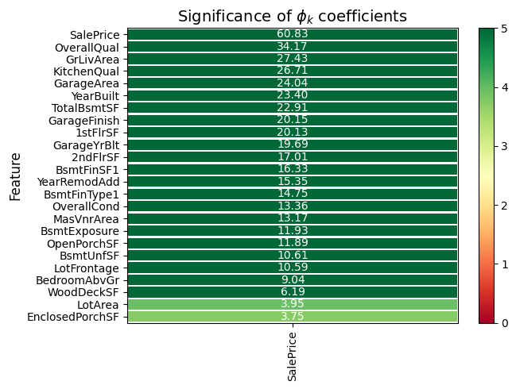

```python
plot_correlation_matrix(pd.DataFrame(significance_matrix_df['SalePrice']).sort_values(by='SalePrice').values,
                                     x_labels=pd.DataFrame(significance_matrix_df['SalePrice']).sort_values(by='SalePrice').columns,
                                     y_labels=pd.DataFrame(significance_matrix_df).sort_values(by='SalePrice').index, y_label='Feature',
                                     title='Significance of $\phi_k$ coefficients', vmin=0, vmax=5)
```

The phi_k coefficient significance values for all SalePrice-feature pairs suggest the phi_k coefficients are statistically significant, with nearly all features having significance values greater than 5 standard deviations. The remaining features have values greater than 3 SD's.

With regard to the coefficients themselves, generally features that have moderate-to-strong spearman correlations, also seem to exhibit a similar strength (with some variation) dependence on sale price, as would be expected. However the '2ndFlrSF' feature exhibits a strong variable dependence with the sale price, despite having a weak spearman (r) value. Additionally the 'MasVnrArea' has a stronger dependence on sale price than what might be expected from its r-value; this could be a consequence of non-monotonic relationships, or the impact of outliers, but, an examination of the scatter plots may reveal this.

### Scatter plots

```python
# creating copy with ordinal encoding reversed
house_prices_df_copy = house_prices_df.copy(deep=True)
house_prices_df_copy[house_prices_categorical_df.columns] = encoder.inverse_transform(X=house_prices_df[house_prices_categorical_df.columns])
```

Saving this unencoded dataframe for use on the dashboard app

```python
try:
    house_prices_df_copy.to_csv(os.path.join(path, 'scatterplot_data_df.csv'), index=True)
except Exception as e:
    print(e)
```

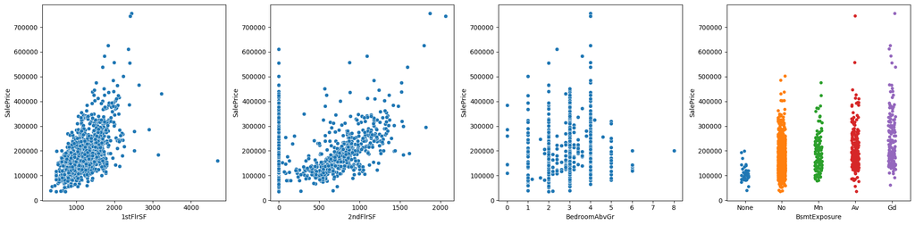

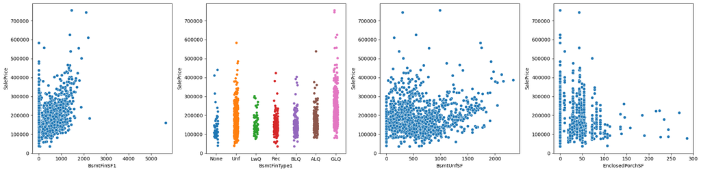

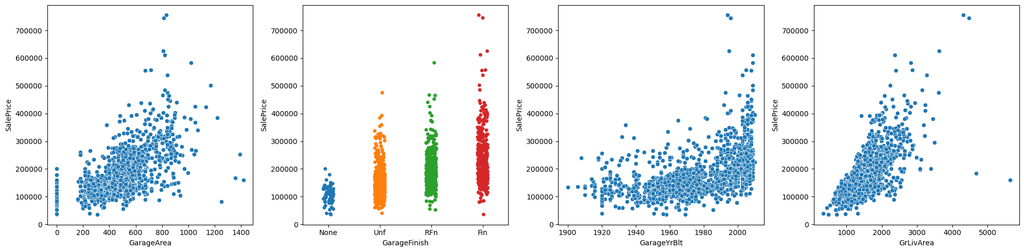

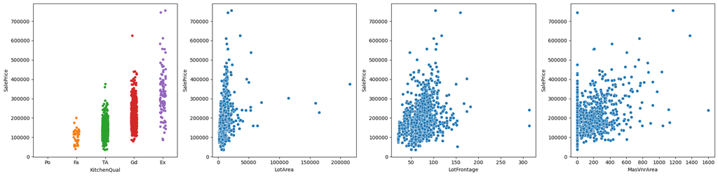

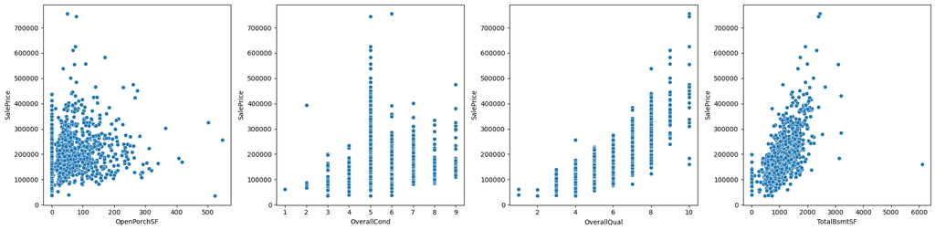

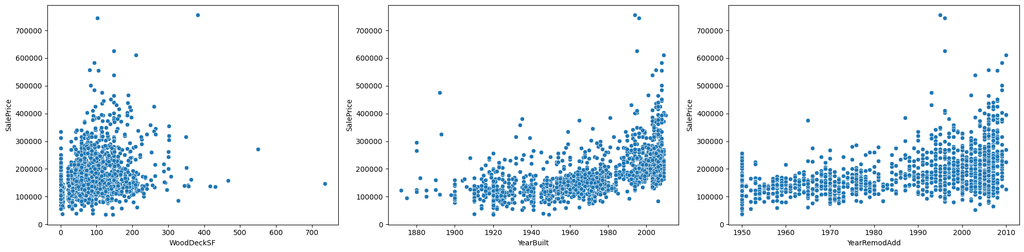

```python
column_names = house_prices_df.columns.tolist()[0:-1]
partitioned_names = []
counter = 0
no_of_groups = int(len(column_names)/4)
while counter < no_of_groups:
    partitioned_names.append(column_names[counter*4:counter*4 + 4])
    counter +=1
partitioned_names.append(column_names[-3:])

for group in partitioned_names:
    fig, axes = plt.subplots(ncols=len(group), nrows=1, figsize=(20,5), tight_layout=True)
    for feature in group:
        order = []
        if feature == 'BsmtExposure':
            order = bsmt_exposure_cat
        elif feature == 'BsmtFinType1':
            order = bsmt_fin_type1_cat
        elif feature == 'GarageFinish':
            order = garage_finish_cat
        elif feature == 'KitchenQual':
            order = kitchen_quality_cat

        if len(order) == 0:
            sns.scatterplot(data=house_prices_df_copy[[feature, 'SalePrice']], x=feature, y='SalePrice', ax=axes[group.index(feature)])
        else:
            sns.stripplot(data=house_prices_df_copy[[feature, 'SalePrice']], x=feature, y='SalePrice', ax=axes[group.index(feature)], order=order)
```

## Predictive Power Score (PPS)

```python
import ppscore as pps
pps_df = pps.predictors(df=house_prices_df, y='SalePrice', sample=1460, cross_validation=10)
pps_df
```

|  | x | y | ppscore | case | is_valid_score | metric | baseline_score | model_score | model |
| --- | --- | --- | --- | --- | --- | --- | --- | --- | --- |
| 0 | OverallQual | SalePrice | 0.442920 | regression | True | mean absolute error | 55533.656164 | 30936.664817 | DecisionTreeRegressor() |
| 1 | KitchenQual | SalePrice | 0.261893 | regression | True | mean absolute error | 55533.656164 | 40989.780224 | DecisionTreeRegressor() |
| 2 | YearBuilt | SalePrice | 0.207124 | regression | True | mean absolute error | 55533.656164 | 44031.277192 | DecisionTreeRegressor() |
| 3 | GarageArea | SalePrice | 0.206953 | regression | True | mean absolute error | 55533.656164 | 44040.801574 | DecisionTreeRegressor() |
| 4 | GarageYrBlt | SalePrice | 0.156235 | regression | True | mean absolute error | 55533.656164 | 46857.347194 | DecisionTreeRegressor() |
| 5 | YearRemodAdd | SalePrice | 0.152323 | regression | True | mean absolute error | 55533.656164 | 47074.628104 | DecisionTreeRegressor() |
| 6 | GarageFinish | SalePrice | 0.134926 | regression | True | mean absolute error | 55533.656164 | 48040.746467 | DecisionTreeRegressor() |
| 7 | EnclosedPorchSF | SalePrice | 0.125920 | regression | True | mean absolute error | 55533.656164 | 48540.831752 | DecisionTreeRegressor() |
| 8 | GrLivArea | SalePrice | 0.108100 | regression | True | mean absolute error | 55533.656164 | 49530.481662 | DecisionTreeRegressor() |
| 9 | WoodDeckSF | SalePrice | 0.103882 | regression | True | mean absolute error | 55533.656164 | 49764.681498 | DecisionTreeRegressor() |
| 10 | BsmtFinType1 | SalePrice | 0.074591 | regression | True | mean absolute error | 55533.656164 | 51391.346278 | DecisionTreeRegressor() |
| 11 | OpenPorchSF | SalePrice | 0.053013 | regression | True | mean absolute error | 55533.656164 | 52589.642054 | DecisionTreeRegressor() |
| 12 | LotFrontage | SalePrice | 0.052577 | regression | True | mean absolute error | 55533.656164 | 52613.859403 | DecisionTreeRegressor() |
| 13 | TotalBsmtSF | SalePrice | 0.049531 | regression | True | mean absolute error | 55533.656164 | 52783.015693 | DecisionTreeRegressor() |
| 14 | OverallCond | SalePrice | 0.047710 | regression | True | mean absolute error | 55533.656164 | 52884.150747 | DecisionTreeRegressor() |
| 15 | BsmtExposure | SalePrice | 0.034731 | regression | True | mean absolute error | 55533.656164 | 53604.918988 | DecisionTreeRegressor() |
| 16 | 2ndFlrSF | SalePrice | 0.016512 | regression | True | mean absolute error | 55533.656164 | 54616.701803 | DecisionTreeRegressor() |
| 17 | 1stFlrSF | SalePrice | 0.000000 | regression | True | mean absolute error | 55533.656164 | 56119.995888 | DecisionTreeRegressor() |
| 18 | BedroomAbvGr | SalePrice | 0.000000 | regression | True | mean absolute error | 55533.656164 | 56044.643344 | DecisionTreeRegressor() |
| 19 | BsmtFinSF1 | SalePrice | 0.000000 | regression | True | mean absolute error | 55533.656164 | 58650.072758 | DecisionTreeRegressor() |
| 20 | BsmtUnfSF | SalePrice | 0.000000 | regression | True | mean absolute error | 55533.656164 | 68660.266374 | DecisionTreeRegressor() |
| 21 | LotArea | SalePrice | 0.000000 | regression | True | mean absolute error | 55533.656164 | 60994.434376 | DecisionTreeRegressor() |
| 22 | MasVnrArea | SalePrice | 0.000000 | regression | True | mean absolute error | 55533.656164 | 58758.651145 | DecisionTreeRegressor() |

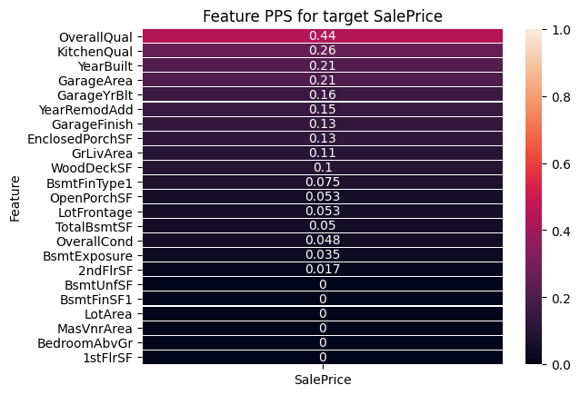

```python
pps_heatmap = sns.heatmap(pps_df.pivot(index='x', columns=['y'], values=['ppscore']).sort_values(by=('ppscore', 'SalePrice'), ascending=False), annot=True,
                                              vmax=1, vmin=0, xticklabels=['SalePrice'], linecolor='white', linewidth=0.05)
pps_heatmap.set(xlabel='', ylabel='Feature', title='Feature PPS for target SalePrice')
pps_heatmap
```

- None of the PPS scores are above 0.5, however this is not surprising since no one feature in this dataset (many features exist) would be expected to account for all variation in the target.

Instead a combination of the most significant features is likely to be able to predict the target more effectively. With this is mind any features with a PPS similar to the feature with the highest PPS, that also demonstrates a strong correlation, is likely to act as a benchmark for a 'good' score.

## Conclusions

**Hypotheses**:

- The common alternative hypothesis (positive monotonic correlation) for all features can be accepted, except for the 'OverallCond' and 'EnclosedPorch' features.

**With regard to the strength of any relationship to the sale price, as implied by the correlation tests**:

- The quality feature group features have a strong relationship to sale price.
- Of the size group features, all but the '2ndFlrSF', 'BedroomAbvGr', 'BsmtUnfSF', 'BsmtFinSF1' have at least moderate Spearman correlation; whilst all but 'LotArea', 'LotFrontage', 'BedroomAbvGr' have at least a moderate dependence on sale price.
- The garage related features have at least a moderate correlation/dependence with sale price.
- On the whole the enclosed porch related feature has a weak relationship to the sale price, whilst the open porch feature may have a moderate relationship.
- Age related features, and the 'MasVnrArea' feature have at least a moderate relationship to the sale price.
- The 'OverallCond', 'BedroomAbvGr' and 'WoodDeckSF' features have a weak relationship to the sale price.

**Scatter plots**:

- The scatter plots largely agree with the relationships implied by the correlation tests.
- They also to some extent explain why certain features appear to have a weak monotonic relationship, but at least a moderate dependence on the sale price: namely because of certain feature values having greater variations in sale price; likewise weak relationships are illustrated in the plots as clustering with less variation.

**PPS**:

multiple features are necessary to predict the sale price.

- However some of the strongest correlated features, also have the largest PPS's.

**Selection of the most significant features for business requirement 2 user story task EDA**:

Based on all metrics used, the following features have been deemed significant enough for further exploratory data analysis:

- '1stFlrSF', '2ndFlrSF', 'BsmtFinSF1', 'GarageArea', 'GarageFinish', 'GarageYrBlt', 'GrLivArea', 'KitchenQual', 'LotArea', 'LotFrontage', 'MasVnrArea', 'OpenPorchSF', 'OverallQual', 'TotalBsmtSF', 'YearBuilt', 'YearRemodAdd'.

```python
import joblib

selected_significant_features = ['1stFlrSF', '2ndFlrSF', 'BsmtFinSF1', 'GarageArea', 'GarageFinish',
                                 'GarageYrBlt', 'GrLivArea', 'KitchenQual', 'LotArea', 'LotFrontage',
                                 'MasVnrArea', 'OpenPorchSF', 'OverallQual', 'TotalBsmtSF', 'YearBuilt',
                                 'YearRemodAdd']

path = os.path.join(os.getcwd(), 'outputs/selected_significant_features.pkl')

joblib.dump(selected_significant_features, path)
```

```
['/workspace/heritage_housing_issues/outputs/selected_significant_features.pkl']
```